# facenet_finetune_2_class

### Fine tuning FaceNet for new faces

This notebook is based on one included facenet-pytorch project: https://github.com/timesler/facenet-pytorch/blob/master/examples/finetune.ipynb

I wanted to try facenet out on some of my own real world pictures, so I trained it on myself and my wife. This notebook will also produce images in a `_result` directory that show the boxes produced by MTCNN as well as labels, probabilities etc. Useful or seeing where misses occur.

I've also extended the MTCNN class from facenet-pytorch so that batch detection outputs can be easily saved off and passed on to extraction in separate steps. Additionally, I created a separate method for selecting a single bounding box per image after NMS has been performed with a new heuristic.

`data_dir` should contain multiple directories, each with images of a single class.

```python
from facenet_pytorch import MTCNN, InceptionResnetV1, fixed_image_standardization, training, extract_face
import torch
from torch.utils.data import DataLoader, SubsetRandomSampler, SequentialSampler
from torch import optim
from torch.optim.lr_scheduler import MultiStepLR
from torch.utils.tensorboard import SummaryWriter
from torchvision import datasets, transforms
import numpy as np
import os
import matplotlib.pyplot as plt
from PIL import Image, ImageDraw, ImageFont
import torch.nn.functional as F
from copy import deepcopy
import shutil
```

```python
data_dir = 'data/zack_erin'

batch_size = 16
epochs = 15
workers = 0 if os.name == 'nt' else 8

classes = ['Erin', 'Zack']
```

```python
#Needed to rotate files based on exif. Default loader strips exif, so can't do in transform step. PIL files don't keep exif when made from MPO file

def exif_rotate_pil_loader(path):
    with open(path, 'rb') as f:
        image = Image.open(f)
        image = reorient_image(image)
        image = image.convert('RGB')  #replicates pil_loader from torchvision. Copies to convert to PIL
    return image


def reorient_image(im):
    try:
        image_exif = im._getexif()
        image_orientation = image_exif[274]
        if image_orientation in (2, '2'):
            return im.transpose(Image.FLIP_LEFT_RIGHT)
        elif image_orientation in (3, '3'):
            return im.transpose(Image.ROTATE_180)
        elif image_orientation in (4, '4'):
            return im.transpose(Image.FLIP_TOP_BOTTOM)
        elif image_orientation in (5, '5'):
            return im.transpose(Image.ROTATE_90).transpose(Image.FLIP_TOP_BOTTOM)
        elif image_orientation in (6, '6'):
            return im.transpose(Image.ROTATE_270)
        elif image_orientation in (7, '7'):
            return im.transpose(Image.ROTATE_270).transpose(Image.FLIP_TOP_BOTTOM)
        elif image_orientation in (8, '8'):
            return im.transpose(Image.ROTATE_90)
        else:
            return im
    except (KeyError, AttributeError, TypeError, IndexError):
        return im


def matplotlib_imshow(img, one_channel=False):
    if one_channel:
        img = img.mean(dim=0)
    img = img / 2 + 0.5  #unnormalize
    npimg = img.cpu().numpy()
    if one_channel:
        plt.imshow(npimg, cmap="Greys")
    else:
        plt.imshow(np.transpose(npimg, (1, 2, 0)))


def images_to_probs(net, images):
    '''
    Generates predictions and corresponding probabilities from a trained
    network and a list of images
    '''
    output = net(images)
    #convert output probabilities to predicted class
    _, preds_tensor = torch.max(output, 1)
    preds = np.squeeze(preds_tensor.cpu().numpy())
    return preds, [F.softmax(el, dim=0)[i].item() for i, el in zip(preds, output)]


def plot_classes_preds(net, images, labels, classes, fig, save_path=None):
    '''
    Generates matplotlib Figure using a trained network, along with images
    and labels from a batch, that shows the network's top prediction along
    with its probability, alongside the actual label, coloring this
    information based on whether the prediction was correct or not.
    Uses the "images_to_probs" function.
    '''
    preds, probs = images_to_probs(net, images)
    #plot the images in the batch, along with predicted and true labels
    #if not fig:
    fig = plt.figure(figsize=(20, 7))
    for idx in np.arange(len(preds)):
        ax = fig.add_subplot(2, np.ceil(len(preds)/2), idx+1, xticks=[], yticks=[])
        matplotlib_imshow(images[idx], one_channel=False)
        ax.set_title("{0}, {1:.1f}%\n(label: {2})".format(
            classes[preds[idx]],
            probs[idx] * 100.0,
            classes[labels[idx]]),
            color=("green" if preds[idx] == labels[idx].item() else "red"))
    if save_path:
        plt.savefig(save_path)
    else:
        return fig
```

```python
class MTCNN_w_batch_extract(MTCNN):
    """custom class that includes addtional methods to allow for easier separation of detection,
        selection and extraction.
    """

    def __init__(self, **kwargs):
        super().__init__(**kwargs)

    def select_boxes(self, all_boxes, all_probs, all_points, method='probability', threshold=.9):
        """Selects a single box from multiple for a given image using one of multiple heuristics.
        Arguments:
                batch_boxes {np.ndarray} -- Nx4 ndarray of bounding boxes for N detected faces (output from self.detect)
                batch_probs {list} -- Length N list of probalities for N detected faces. (output from self.detect)
        Keyword Arguments:
                method {str} -- Which heuristic to use for selection:
                    "probability": highest probability selected
                    "largest": largest box selected
                    "largest_over_theshold": largest box over a certain probability threshold selected
                threshold {float} -- theshold for "largest_over_threshold" method

        Returns:
                tuple(numpy.ndarray, numpy.ndarray) -- Ix4 ndarray of bounding boxes for I images. Ix0 array of probabilities for each box
        """
        selected_boxes, selected_probs, selected_points = [], [], []
        for boxes, points, probs in zip(all_boxes, all_points, all_probs):
            boxes = np.array(boxes)
            probs = np.array(probs)
            points = np.array(points)
            if len(boxes) == 0:
                selected_boxes.append(None)
                selected_probs.append([None])
                selected_points.append(None)
                continue
            elif method == 'largest':
                box_order = np.argsort((boxes[:, 2] - boxes[:, 0]) * (boxes[:, 3] - boxes[:, 1]))[::-1]
            elif method == 'probability':
                box_order = np.argsort(probs)[::-1]
            elif method == 'largest_over_threshold':
                box_mask = probs > threshold
                boxes = boxes[box_mask]
                box_order = np.argsort((boxes[:, 2] - boxes[:, 0]) * (boxes[:, 3] - boxes[:, 1]))[::-1]
                if sum(box_mask) == 0:
                    selected_boxes.append(None)
                    selected_probs.append([None])
                    selected_points.append(None)
                    continue

            box = boxes[box_order][[0]]
            prob = probs[box_order][[0]]
            point = points[box_order][[0]]
            selected_boxes.append(box)
            selected_probs.append(prob)
            selected_points.append(point)

        selected_boxes = np.array(selected_boxes)
        selected_probs = np.array(selected_probs)
        selected_points = np.array(selected_points)

        return selected_boxes, selected_probs, selected_points

    def extract(self, img, batch_boxes, save_path):
        #Determine if a batch or single image was passed
        batch_mode = True
        if not isinstance(img, (list, tuple)) and not (isinstance(img, np.ndarray) and len(img.shape) == 4):
            img = [img]
            batch_boxes = [batch_boxes]
            batch_mode = False

        #Parse save path(s)
        if save_path is not None:
            if isinstance(save_path, str):
                save_path = [save_path]
        else:
            save_path = [None for _ in range(len(img))]

        #Process all bounding boxes
        faces = []
        for im, box_im, path_im in zip(img, batch_boxes, save_path):
            if box_im is None:
                faces.append(None)
                continue

            if not self.keep_all:
                box_im = box_im[[0]]

            faces_im = []
            for i, box in enumerate(box_im):
                face_path = path_im
                if path_im is not None and i > 0:
                    save_name, ext = os.path.splitext(path_im)
                    face_path = save_name + '_' + str(i + 1) + ext

                face = extract_face(im, box, self.image_size, self.margin, face_path)
                if self.post_process:
                    face = fixed_image_standardization(face)
                faces_im.append(face)

            if self.keep_all:
                faces_im = torch.stack(faces_im)
            else:
                faces_im = faces_im[0]

            faces.append(faces_im)

        if not batch_mode:
            faces = faces[0]

        return faces
```

#### Determine if an nvidia GPU is available

```python
device = torch.device('cuda:0' if torch.cuda.is_available() else 'cpu')
print('Running on device: {}'.format(device))
```

```
Running on device: cuda:0
```

```python
mtcnn = MTCNN_w_batch_extract(
    image_size=160,
    margin=0,
    min_face_size=20,
    thresholds=[0.6, 0.7, 0.7],
    factor=0.709,
    post_process=True,
    select_largest=False,
    device=device
)
```

```python
#Define the data loader for the input set of images
orig_img_ds = datasets.ImageFolder(data_dir, loader=exif_rotate_pil_loader, transform=transforms.Resize((1024, 1024)))
```

```python
#overwrites class labels in dataset with path so path can be used for saving output in mtcnn batches
orig_img_ds.samples = [
    (p, p)
    for p, _ in orig_img_ds.samples
]

loader = DataLoader(
    orig_img_ds,
    num_workers=workers,
    batch_size=batch_size,
    collate_fn=training.collate_pil
)
```

```python
boxes = []
box_probs = []
paths = []
for i, (x, b_paths) in enumerate(loader):
    crops = [p.replace(data_dir, data_dir + '_cropped') for p in b_paths]
    #for now, doing two forward passes. One for detection and one for extraction. #TODO: make custom MTCNN class that has option for both
    b_boxes, b_box_probs, points = mtcnn.detect(x, landmarks=True)
    b_boxes, b_box_probs, points = mtcnn.select_boxes(b_boxes, b_box_probs, points, method='largest_over_threshold')
    mtcnn.extract(x, b_boxes, save_path=crops)

    boxes.extend(b_boxes)
    box_probs.extend(b_box_probs)
    paths.extend(b_paths)

    print('\rBatch {} of {}'.format(i + 1, len(loader)), end='')
```

```
Batch 1 of 12
```

```
Batch 12 of 12
```

```python
#Remove mtcnn to reduce GPU memory usage
del mtcnn
```

```python
#create dataset and data loaders from cropped images output from MTCNN

trans = transforms.Compose([
    np.float32,
    transforms.ToTensor(),
    fixed_image_standardization
])

dataset = datasets.ImageFolder(data_dir + '_cropped', transform=trans)
img_inds = np.arange(len(dataset))
np.random.shuffle(img_inds)
train_inds = img_inds[:int(0.8 * len(img_inds))]
val_inds = img_inds[int(0.8 * len(img_inds)):]

train_loader = DataLoader(
    dataset,
    num_workers=workers,
    batch_size=batch_size,
    sampler=SubsetRandomSampler(train_inds)
)
val_loader = DataLoader(
    dataset,
    num_workers=workers,
    batch_size=batch_size,
    sampler=SubsetRandomSampler(val_inds)
)

#Load pretrained resnet model
resnet = InceptionResnetV1(
    classify=True,
    pretrained='vggface2',
    num_classes=len(dataset.class_to_idx)
).to(device)
```

#### Define optimizer, scheduler, dataset, and dataloader

```python
optimizer = optim.Adam(resnet.parameters(), lr=0.001)
scheduler = MultiStepLR(optimizer, [5, 10])
```

```python
loss_fn = torch.nn.CrossEntropyLoss()
metrics = {
    'fps': training.BatchTimer(),
    'acc': training.accuracy
}
```

```python
writer = SummaryWriter()
writer.iteration, writer.interval = 0, 10

print('\n\nInitial')
print('-' * 10)
resnet.eval()
training.pass_epoch(
    resnet, loss_fn, val_loader,
    batch_metrics=metrics, show_running=True, device=device,
    writer=writer
)

for epoch in range(epochs):
    print('\nEpoch {}/{}'.format(epoch + 1, epochs))
    print('-' * 10)

    resnet.train()
    training.pass_epoch(
        resnet, loss_fn, train_loader, optimizer, scheduler,
        batch_metrics=metrics, show_running=True, device=device,
        writer=writer
    )

    resnet.eval()
    training.pass_epoch(
        resnet, loss_fn, val_loader,
        batch_metrics=metrics, show_running=True, device=device,
        writer=writer
    )


writer.close()
```

```
Initial
----------
Valid |     3/3    | loss:    0.7294 | fps:  196.9552 | acc:    0.4931

----------
Train |    10/10   | loss:    0.4667 | fps:  157.2292 | acc:    0.8238
Valid |     3/3    | loss:   51.4171 | fps:  329.3969 | acc:    0.4931

----------
Train |    10/10   | loss:    0.2514 | fps:  157.8248 | acc:    0.9062
Valid |     3/3    | loss:    2.0264 | fps:  352.8290 | acc:    0.7500

----------
Train |    10/10   | loss:    0.1762 | fps:  163.5132 | acc:    0.9488
Valid |     3/3    | loss:    1.0411 | fps:  351.2666 | acc:    0.8194

----------
Train |    10/10   | loss:    0.4083 | fps:  158.4965 | acc:    0.9238
Valid |     3/3    | loss:    0.2508 | fps:  351.0291 | acc:    0.9375

----------
Train |    10/10   | loss:    0.1495 | fps:  163.2209 | acc:    0.9438
Valid |     3/3    | loss:    0.3577 | fps:  347.0696 | acc:    0.8750

----------
Train |    10/10   | loss:    0.2800 | fps:  155.9789 | acc:    0.9275
Valid |     3/3    | loss:    0.2854 | fps:  350.2227 | acc:    0.8819

----------
Train |    10/10   | loss:    0.0773 | fps:  163.1457 | acc:    0.9800
Valid |     3/3    | loss:    0.2705 | fps:  345.0395 | acc:    0.8819

----------
Train |    10/10   | loss:    0.1030 | fps:  156.8242 | acc:    0.9563
Valid |     3/3    | loss:    0.2152 | fps:  352.0307 | acc:    0.9167

----------
Train |    10/10   | loss:    0.0544 | fps:  163.3841 | acc:    1.0000
Valid |     3/3    | loss:    0.2115 | fps:  343.2190 | acc:    0.9375

```

[output cut: 8 more lines]

```
----------
Train |    10/10   | loss:    0.0392 | fps:  158.6553 | acc:    0.9937
Valid |     3/3    | loss:    0.2406 | fps:  362.2161 | acc:    0.9375

----------
Train |    10/10   | loss:    0.0409 | fps:  160.0191 | acc:    0.9937
Valid |     3/3    | loss:    0.2118 | fps:  344.6400 | acc:    0.9375

----------
Train |    10/10   | loss:    0.0357 | fps:  155.7089 | acc:    1.0000
Valid |     3/3    | loss:    0.2264 | fps:  341.1480 | acc:    0.9375

----------
Train |    10/10   | loss:    0.0367 | fps:  162.9640 | acc:    1.0000
Valid |     3/3    | loss:    0.4253 | fps:  340.7551 | acc:    0.9028
```

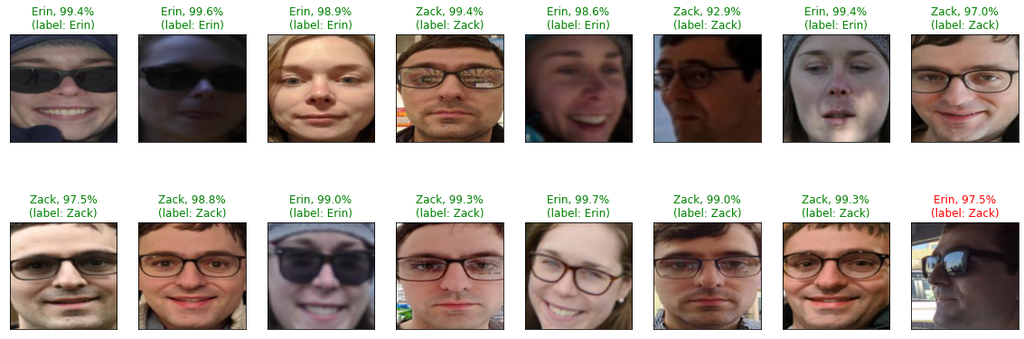

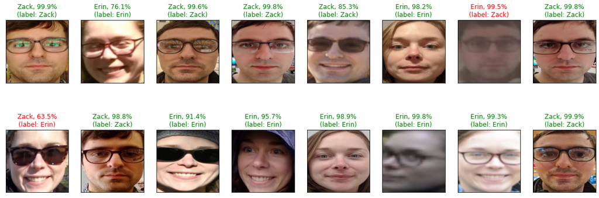

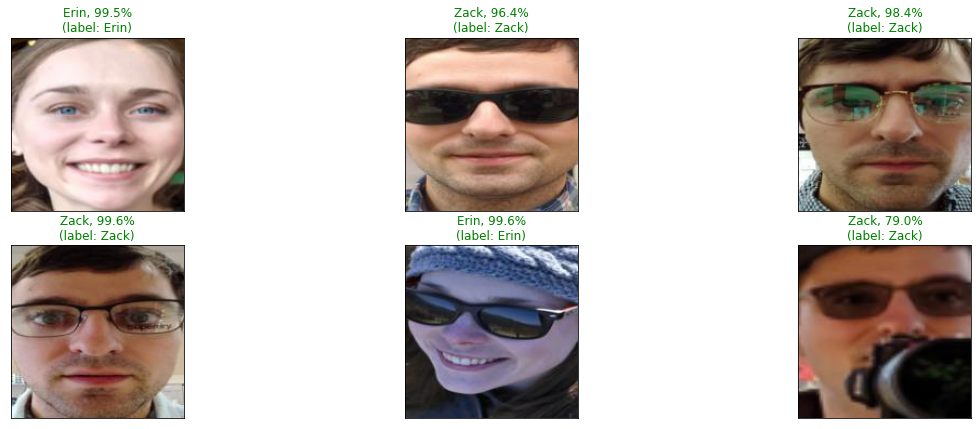

```python
#create new DS that has both train and val. Used for drawing on images and showing probs

viz_loader = DataLoader(
    dataset,
    num_workers=workers,
    batch_size=batch_size,
    sampler=SequentialSampler(dataset)
)

val_sets = ['training', 'validation']
preds = []
probs = []
labels = []
val_set = np.zeros(len(dataset), dtype=int)
val_set[val_inds] = 1

#plots all validation images with probability, pred and whether correct
for xb, yb in val_loader:
    xb = xb.to(device)
    yb = yb.to(device)
    plot_classes_preds(resnet, xb, yb, classes, fig=None) #, save_path=data_dir+'val_summary.png')

#Grabs preds, probabilities and labels for all images so they can be used in next step
for xb, yb in viz_loader:
    xb = xb.to(device)
    yb = yb.to(device)
    b_preds, b_probs = images_to_probs(resnet, xb)
    preds.extend(b_preds)
    probs.extend(b_probs)
    labels.extend(yb)

img_output = dict(zip(paths, zip(boxes, box_probs, preds, probs, labels, val_set)))
```

```python
save_dir = data_dir + '_result'
shutil.rmtree(save_dir, ignore_errors=True)
os.makedirs(save_dir + '/val/Erin')
os.makedirs(save_dir + '/val/Zack')
os.makedirs(save_dir + '/train/Erin')
os.makedirs(save_dir + '/train/Zack')
font = ImageFont.truetype("FreeSansBold.ttf", 90)

for k, v in img_output.items():
    img = reorient_image(Image.open(k)).copy()
    draw = ImageDraw.Draw(img)
    box_vals = deepcopy(v[0])
    box_probs = deepcopy(v[1])
    label_pred = deepcopy(v[2])
    label_prob = deepcopy(v[3])
    label = deepcopy(v[4])
    validation = deepcopy(v[5])
    if validation:
        save_path = k.replace(data_dir, save_dir + '/val')
    else:
        save_path = k.replace(data_dir, save_dir + '/train')
    if box_vals is not None:
        for i, box in enumerate(box_vals):
            resize_width = img.width / 1024
            resize_height = img.height / 1024
            box[0] *= resize_width
            box[2] *= resize_width
            box[1] *= resize_height
            box[3] *= resize_height
            draw.rectangle(tuple(box), outline='cyan', width=6)
            draw.text((box[0], box[3] + 80), fill='cyan', font=font, text=str(box_probs[i]))
            if i == 0:  #assumes boxes have been ordered same as what was fed to resnet
                draw.text((box[0], box[3] + 160), fill=((0, 255, 0) if label_pred == label else (255, 0, 0)),
                          font=font, text=f'{classes[label_pred]}: {label_prob} \n{val_sets[validation]} ')
                #draw.text((box[0], box[3]+240), font=font, text=f'{val_sets[validation]}')

    img.save(save_path)
```

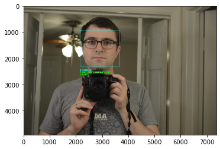

```python
path = save_dir+'/train/Zack'
example = os.listdir(path)[0]
img = Image.open(path+'/'+example)
plt.imshow(img)
```

### Notes

Accuracy is worse than LFW for FaceNet. Some of the pics I chose were much harder than most LFW though (side angle, hats, etc). Still likely that trying to train classifier on top of deep features hurts accuracy.

Regardless, need to redo with similarity scores.